# Process model uncertainity

```r
library(tidyverse)
library(lubridate)
library(arrow)
source("https://raw.githubusercontent.com/frec-5174/eco4cast-in-R-book/main/R/helpers.R")
source("https://raw.githubusercontent.com/frec-5174/eco4cast-in-R-book/main/R/forest_model.R")
set.seed(123)
```

## Setting up simulations

```r
sim_dates <- seq(as_date("2023-11-15"),length.out  = 34, by = "1 day")
```

```r
site <- "OSBS"
```

### Baseline parameters

This are the parameters that will be used for all the simulations except for the simulation where parameter uncertainty is propagated

```r
ens_members <- 100
params <- list()
params$alpha <- rep(0.02, ens_members)
params$SLA <- rep(4.74, ens_members)
params$leaf_frac <- rep(0.315, ens_members)
params$Ra_frac <- rep(0.5, ens_members)
params$Rbasal <- rep(0.002, ens_members)
params$Q10 <- rep(2.1, ens_members)
params$litterfall_rate <- rep(1/(2.0*365), ens_members) #Two year leaf lifespan
params$litterfall_start <- rep(200, ens_members)
params$litterfall_length<- rep(70, ens_members)
params$mortality <- rep(0.00015, ens_members) #Wood lives about 18 years on average (all trees, branches, roots, course roots)
params$sigma.leaf <- rep(0.0, ens_members) #0.01
params$sigma.stem <- rep(0.0, ens_members) #0.01 ## wood biomass
params$sigma.soil <- rep(0.0, ens_members)# 0.01
params <- as.data.frame(params)
```

### Baseline initial conditions

This are the initial conditions that will be used for all the simulations except for the simulation where initial uncertainty is propagated

```r
#Set initial conditions
output <- array(NA, dim = c(length(sim_dates), ens_members, 12)) #12 is the number of outputs
output[1, , 1] <- 5
output[1, , 2] <- 140
output[1, , 3] <- 140
```

### Baseline drivers

This are the drivers conditions that will be used for all the simulations except for the simulation where driver uncertainty is propagated. It uses the mean for the weather forecast ensemble.

```r
inputs <- get_forecast_met(site = site, sim_dates, use_mean = TRUE)
inputs_ensemble <- assign_met_ensembles(inputs, ens_members)
```

## Parameter uncertainty

Our model has 13 parameters. Each of them require a value that is likely not known with perfect uncertainty. Representing parameter uncertainty involves replacing the single value for each parameter with a distribution. The distribution can be from literature reviews, a best guess, or the outcome of a calibration exercise. The the calibration exercise is Bayesian the distribution of the parameter before calibration can be refereed to as a prior and after calibration is a posterior. Sampling from the parameter distribution provides values for the parameter that are assigned to each ensemble member.

In many cases a sensitivity analysis can be used to determine which parameters to focus uncertainty estimation on. If a model is not particularly sensitive to parameter then the prediction uncertainty is less likely to be strongly determined by the uncertainty in that parameter. In practices, the values for the less sensitive parameters are held at a single value. Other parameters are so well known that they are also held at a single value (e.g., the gravitation constant).

In this example, I focuses only on propagating one parameter (`alpha`) that represents the light use efficiency of photosynthesis. All other parameters are held at their baseline values.

```r
new_params <- params
new_params$alpha <- rnorm(ens_members, params$alpha, sd = 0.005)
```

This results in `alpha` having the following distribution Figure 1:

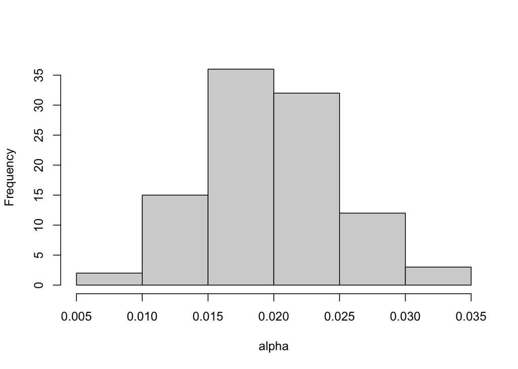

Figure 1: Histogram showing the distribution of the parameter alpha

Use the `new_params` as the parameters in the simulation.

```r
for(t in 2:length(sim_dates)){

  output[t, , ]  <- forest_model(t,
                               states = matrix(output[t-1 , , 1:3], nrow = ens_members) ,
                               parms = new_params,
                               inputs = matrix(inputs_ensemble[t ,, ], nrow = ens_members))
}

parameter_df <- output_to_df(output, sim_dates, sim_name = "parameter_unc")
```

Figure 2 shows the forecast that only includes parameter uncertainty

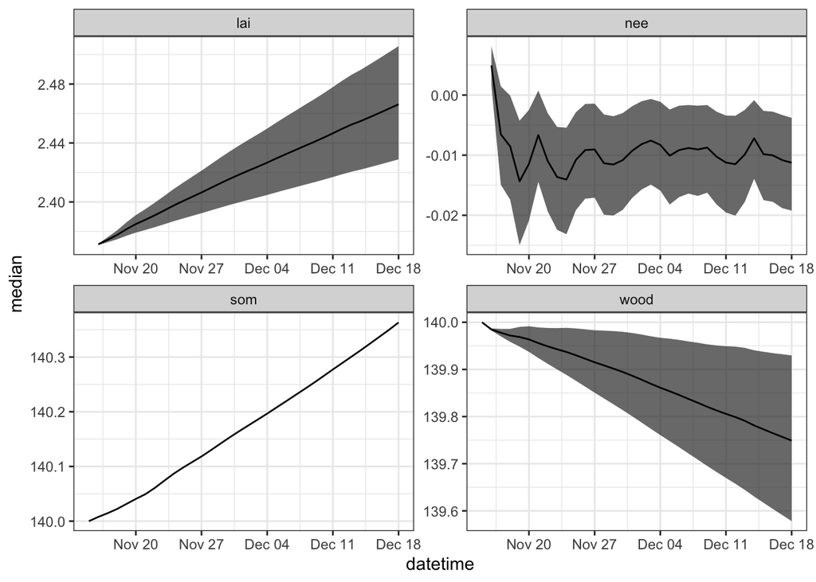

Figure 2: Forecast with parameter uncertainty

```r
parameter_df |>
  filter(variable %in% c("lai", "wood", "som", "nee")) |>
  summarise(median = median(prediction, na.rm = TRUE),
            upper90 = quantile(prediction, 0.95, na.rm = TRUE),
            lower90 = quantile(prediction, 0.05, na.rm = TRUE),
            .by = c("datetime", "variable")) |>
  ggplot(aes(x = datetime)) +
  geom_ribbon(aes(ymin = lower90, ymax = upper90), alpha = 0.7) +
  geom_line(aes(y = median)) +
  facet_wrap(~variable, scale = "free") +
  theme_bw()
```

## Process uncertainty

Process uncertainty is the uncertainty that comes from the model being a simplification of reality. We can use random noise to capture the dynamics that are missing from the model. The random noise is added to each state as end model timestep. The random noise is normally distributed with a mean equal to the model prediction for that time-step and the standard deviation equal to the parameters `sigma.leaf` (or leaves), `sigma.stem` (for wood), and `sigma.soil` (SOM). The result is a random walk that is guided by the mean prediction of the process model.

```r
new_params <- params
new_params$sigma.leaf <- rep(0.1, ens_members)
new_params$sigma.stem <- rep(1, ens_members) #0.01 ## wood biomass
new_params$sigma.soil <- rep(1, ens_members)# 0.01
```

As an example Figure 3 shows the distribution in the noise that is added the leaf state at each time step.

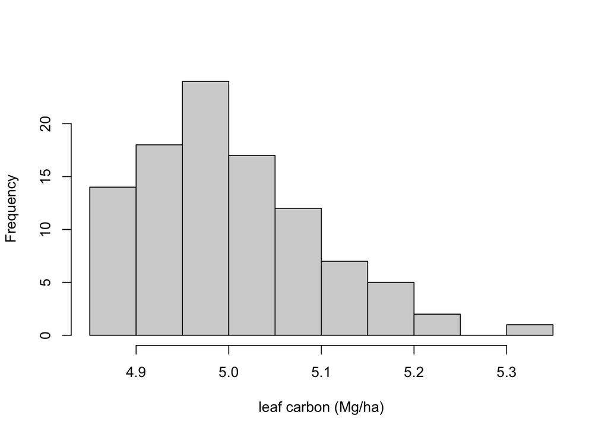

Figure 3: Histogram of the distribution of process uncertainty added to leaf carbon

```r
for(t in 2:length(sim_dates)){

  output[t, , ]  <- forest_model(t,
                               states = matrix(output[t-1 , , 1:3], nrow = ens_members) ,
                               parms = new_params,
                               inputs = matrix(inputs_ensemble[t ,, ], nrow = ens_members))
}

process_df <- output_to_df(output, sim_dates, sim_name = "process_unc")
```

Figure 4 shows the forecast that only includes process uncertainty

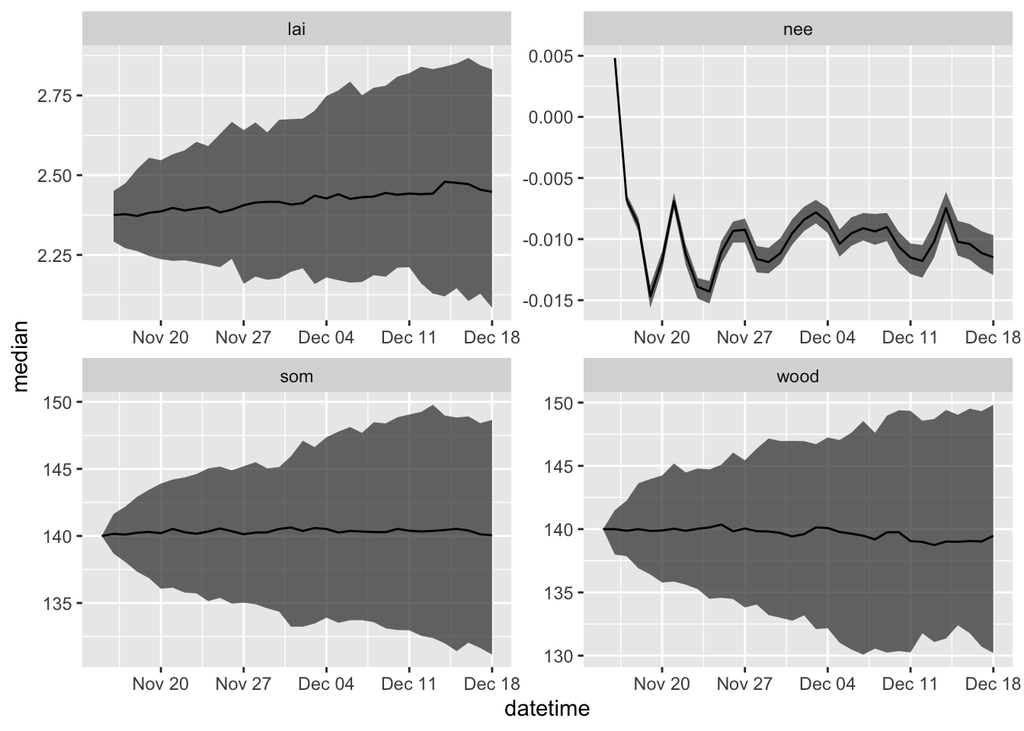

Figure 4: Forecast with process uncertainty

```r
process_df |>
  filter(variable %in% c("lai", "wood", "som", "nee")) |>
  summarise(median = median(prediction, na.rm = TRUE),
            upper90 = quantile(prediction, 0.95, na.rm = TRUE),
            lower90 = quantile(prediction, 0.05, na.rm = TRUE),
            .by = c("datetime", "variable")) |>
  ggplot(aes(x = datetime)) +
  geom_ribbon(aes(ymin = lower90, ymax = upper90), alpha = 0.7) +
  geom_line(aes(y = median)) +
  facet_wrap(~variable, scale = "free")
```

## Initial condition uncertainty

Initial condition uncertainty is the spread in the model states at the first time-step of a forecast. This spread would be due to a lack of measurements (thus no direct knowledge of the state) or uncertainty in measurements (there is a spread in the possible states because we can’t perfectly observe it.). Here we represent initial condition uncertainty by generating a normal distribution with a mean equal to the observed value (or our best guess) and a standard deviation that represents measurement uncertainty. We update the initial starting point in the forecast with this distribution.

```r
#Set initial conditions
new_output <- array(NA, dim = c(length(sim_dates), ens_members, 12)) #12 is the number of outputs
new_output[1, , 1] <- rnorm(ens_members, 5, 0.5)
new_output[1, , 2] <- rnorm(ens_members, 140, 10)
new_output[1, , 3] <- rnorm(ens_members, 140, 20)
```

As an example Figure 5 shows the distribution in the noise that is added the initial leaf state.

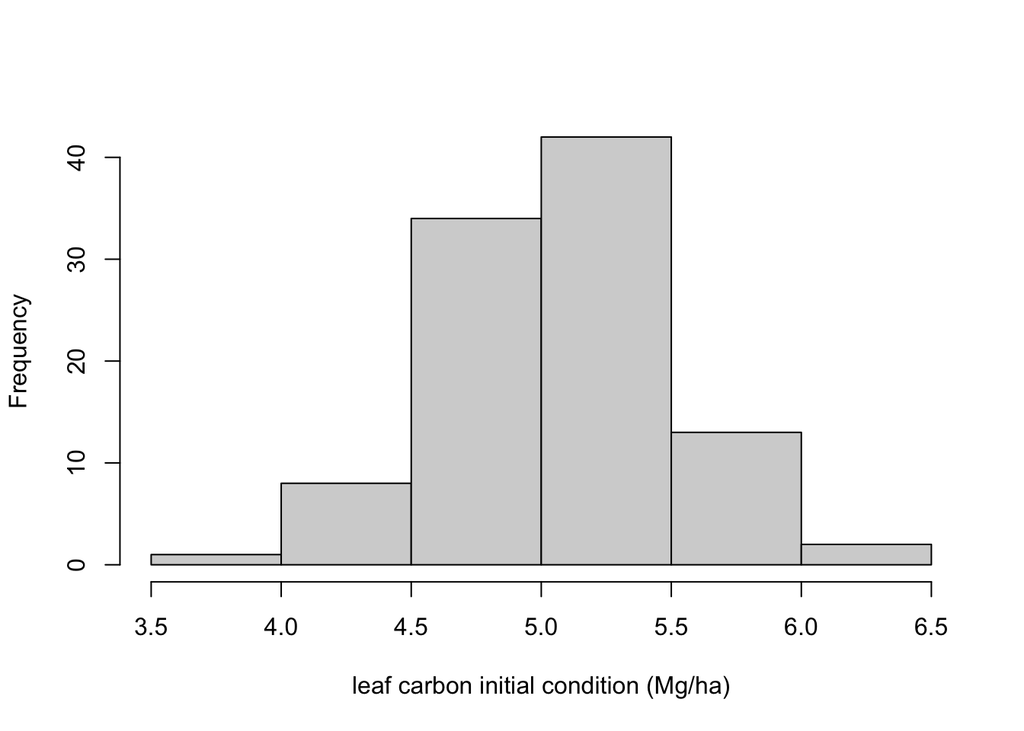

Figure 5: Distribution of intial condition uncertainty for leaf carbon (Mg/ha)

```r
for(t in 2:length(sim_dates)){

  new_output[t, , ]  <- forest_model(t,
                               states = matrix(new_output[t-1 , , 1:3], nrow = ens_members) ,
                               parms = params,
                               inputs = matrix(inputs_ensemble[t ,, ], nrow = ens_members))
}

initial_conditions_df <- output_to_df(new_output, sim_dates, sim_name = "initial_unc")
```

Figure 6 shows the forecast that only includes initial condition uncertainty

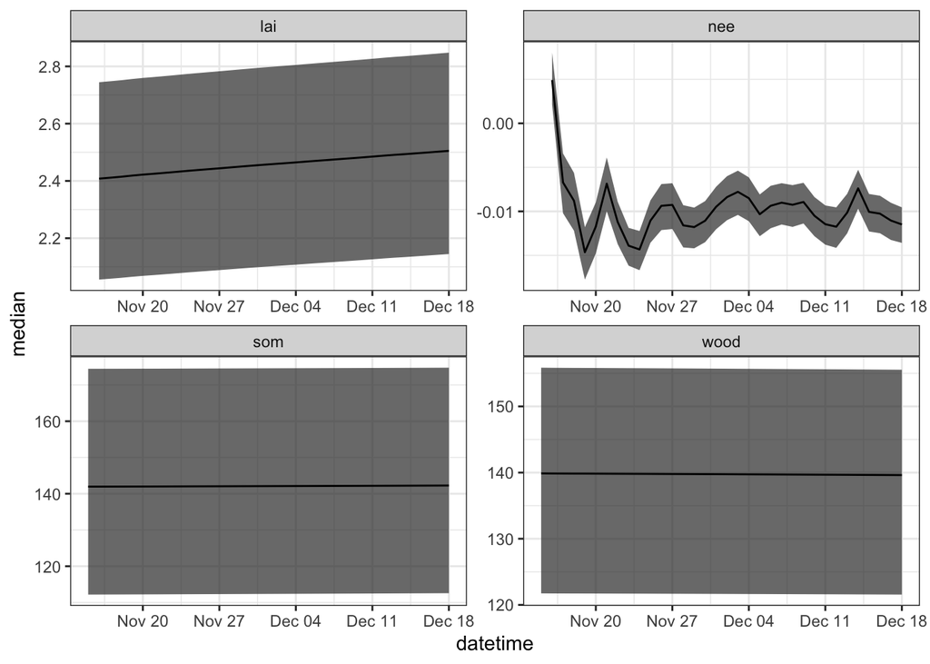

Figure 6: Forecast with initial condition uncertainty

```r
initial_conditions_df |>
  filter(variable %in% c("lai", "wood", "som", "nee")) |>
  summarise(median = median(prediction, na.rm = TRUE),
            upper90 = quantile(prediction, 0.95, na.rm = TRUE),
            lower90 = quantile(prediction, 0.05, na.rm = TRUE),
            .by = c("datetime", "variable")) |>
  ggplot(aes(x = datetime)) +
  geom_ribbon(aes(ymin = lower90, ymax = upper90), alpha = 0.7) +
  geom_line(aes(y = median)) +
  facet_wrap(~variable, scale = "free")  +
  theme_bw()
```

## Driver uncertainty

The uncertainty in the weather forecasts comes directly from the 31 ensembles provided by the NOAA Global Ensemble Forecasting System (GEFS). The ensemble is generated by slightly changing (perturbing) the initial states in the weather model before starting the forecast. Due to the chaotic nature of the atmosphere, the small differences get amplified over time, resulting in spread that increases further in the future.

```r
new_inputs <- get_forecast_met(site = site, sim_dates, use_mean = FALSE)
new_inputs_ensemble <- assign_met_ensembles(new_inputs, ens_members)
```

As an example Figure 7 shows 31 ensemble members from single 35-day forecast generated by NOAA GEFS.

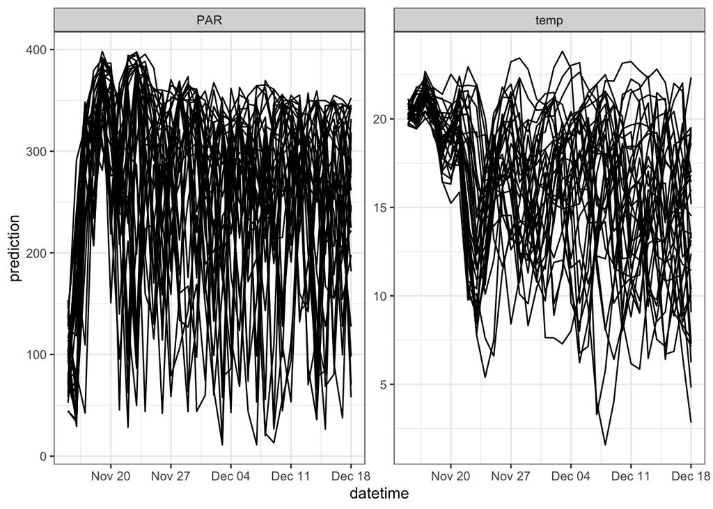

Figure 7: 35-day ahead forecasts from NOAA GEFS of the two variables using by the process model.

```r
for(t in 2:length(sim_dates)){

  output[t, , ]  <- forest_model(t,
                               states = matrix(output[t-1 , , 1:3], nrow = ens_members) ,
                               parms = params,
                               inputs = matrix(new_inputs_ensemble[t ,, ], nrow = ens_members))
}

drivers_df <- output_to_df(output, sim_dates, sim_name = "driver_unc")
```

Figure 8 shows the forecast that only includes driver uncertainty

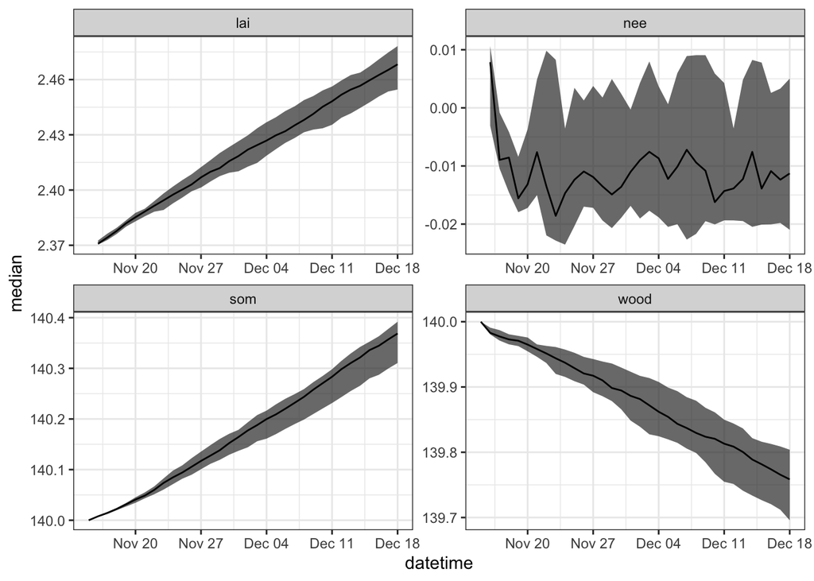

Figure 8: Forecast with driver uncertainty

```r
drivers_df |>
  filter(variable %in% c("lai", "wood", "som", "nee")) |>
  summarise(median = median(prediction, na.rm = TRUE),
            upper90 = quantile(prediction, 0.95, na.rm = TRUE),
            lower90 = quantile(prediction, 0.05, na.rm = TRUE),
            .by = c("datetime", "variable")) |>
  ggplot(aes(x = datetime)) +
  geom_ribbon(aes(ymin = lower90, ymax = upper90), alpha = 0.7) +
  geom_line(aes(y = median)) +
  facet_wrap(~variable, scale = "free") +
  theme_bw()
```

## Problem Set

### Part 1

Using a dataset that combines each of the uncertainty dataframes into a single data frame:

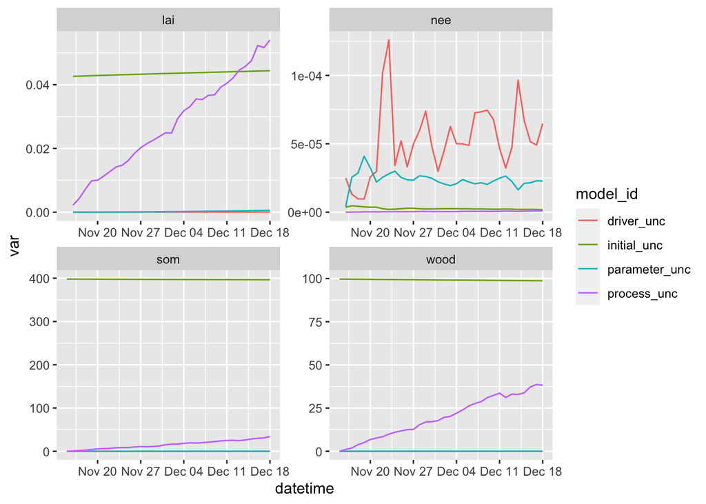

```r
combined_df <- bind_rows(parameter_df, process_df, initial_conditions_df, drivers_df)

var_df<-combined_df %>%
  group_by(model_id, datetime, variable) %>%
  summarize(variance=var(prediction))
#ANSWER FROM CLASS#
combined_df |>
  filter(variable %in% c("lai", "wood", "som", "nee")) |>
  summarize(var = var(prediction, na.rm = T),
            .by = c("model_id", "datetime", "variable")) |>
  ggplot() +
  geom_line(aes(x=datetime, y=var, color=model_id)) +
  facet_wrap(~variable, scale="free")
```

Answer with text, code, and plots the following questions

1. 1 day-ahead, what the largest source of uncertainty for a flux (nee)? for a state (wood)?

```r
var_df %>% filter(variable=="nee", datetime=="2023-11-16")
```

```
# A tibble: 4 × 4
# Groups:   model_id, datetime [4]
  model_id      datetime   variable   variance
  <chr>         <date>     <chr>         <dbl>
1 driver_unc    2023-11-16 nee      0.0000249
2 initial_unc   2023-11-16 nee      0.00000361
3 parameter_unc 2023-11-16 nee      0.00000414
4 process_unc   2023-11-16 nee      0
```

The largest source of uncertainty for a flux (NEE) one day ahead is driver uncertainty, based on the fact that driver uncertainty has the largest variance around the mean for datetime t=2. Process uncertainty has a variance of zero at datetime t=2.

```r
var_df %>% filter(variable=="wood", datetime=="2023-11-16")
```

```
# A tibble: 4 × 4
# Groups:   model_id, datetime [4]
  model_id      datetime   variable    variance
  <chr>         <date>     <chr>          <dbl>
1 driver_unc    2023-11-16 wood      0.0000141
2 initial_unc   2023-11-16 wood     99.7
3 parameter_unc 2023-11-16 wood      0.00000194
4 process_unc   2023-11-16 wood      1.07
```

The largest source of uncertainty for a state (wood) one day ahead is initial condition uncertainty, based on the fact that initial condition has the largest variance around the mean for datetime t=2.

2. 10 days-ahead, what is the largest source of uncertainty for a flux (nee)? for a state (wood)?

```r
var_df %>% filter(variable=="nee", datetime=="2023-11-25")
```

```
# A tibble: 4 × 4
# Groups:   model_id, datetime [4]
  model_id      datetime   variable    variance
  <chr>         <date>     <chr>          <dbl>
1 driver_unc    2023-11-25 nee      0.0000522
2 initial_unc   2023-11-25 nee      0.00000255
3 parameter_unc 2023-11-25 nee      0.0000254
4 process_unc   2023-11-25 nee      0.000000316
```

The largest source of uncertainty for a flux (NEE) ten days ahead is again driver uncertainty, based on the fact that driver uncertainty has the largest variance around the mean for datetime t=10.

```r
var_df %>% filter(variable=="wood", datetime=="2023-11-25")
```

```
# A tibble: 4 × 4
# Groups:   model_id, datetime [4]
  model_id      datetime   variable  variance
  <chr>         <date>     <chr>        <dbl>
1 driver_unc    2023-11-25 wood      0.000225
2 initial_unc   2023-11-25 wood     99.4
3 parameter_unc 2023-11-25 wood      0.00118
4 process_unc   2023-11-25 wood     11.8
```

The largest source of uncertainty for a state (wood) ten days ahead is initial condition uncertainty, based on the fact that initial condition has the largest variance around the mean for datetime t=10.

3. 30 days-ahead, what is the largest source of uncertainty for a flux (nee)? for a state (wood)?

```r
var_df %>% filter(variable=="nee", datetime=="2023-12-15")
```

```
# A tibble: 4 × 4
# Groups:   model_id, datetime [4]
  model_id      datetime   variable    variance
  <chr>         <date>     <chr>          <dbl>
1 driver_unc    2023-12-15 nee      0.0000669
2 initial_unc   2023-12-15 nee      0.00000200
3 parameter_unc 2023-12-15 nee      0.0000211
4 process_unc   2023-12-15 nee      0.000000775
```

The largest source of uncertainty for a flux (NEE) thirty days ahead is again driver uncertainty, based on the fact that driver uncertainty has the largest variance around the mean for datetime t=30.

```r
var_df %>% filter(variable=="wood", datetime=="2023-12-15")
```

```
# A tibble: 4 × 4
# Groups:   model_id, datetime [4]
  model_id      datetime   variable  variance
  <chr>         <date>     <chr>        <dbl>
1 driver_unc    2023-12-15 wood      0.000686
2 initial_unc   2023-12-15 wood     98.8
3 parameter_unc 2023-12-15 wood      0.00980
4 process_unc   2023-12-15 wood     33.9
```

The largest source of uncertainty for a state (wood) thirty days ahead is again initial condition uncertainty, based on the fact that initial condition has the largest variance around the mean for datetime t=30.

The consistency across time steps for the largest contributions to uncertainty are confirmed when I plot uncertainty for each variable. Figure 9 shows driver uncertainty as the widest (greatest) variance compared to other uncertainty sources for NEE. Figure 10 shows initial condition uncertainty as the widest (greatest) variance compared to other uncertainty sources for Wood.

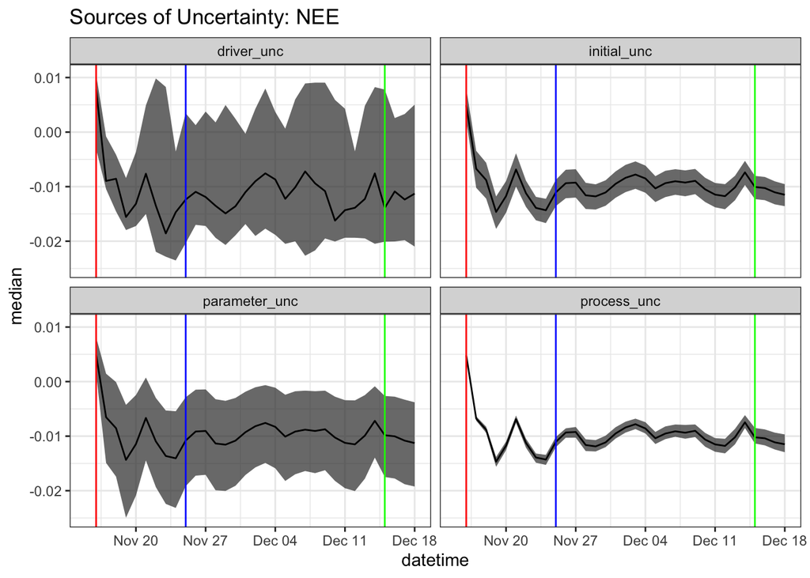

Figure 9: Forecast of each uncertainty source for NEE. One day ahead indicated by red line. Ten days ahead indicated by blue line. Thirty days ahead indicated by green line.

```r
combined_df %>% filter(variable=="nee") %>%
  summarise(median = median(prediction, na.rm = TRUE),
            upper90 = quantile(prediction, 0.95, na.rm = TRUE),
            lower90 = quantile(prediction, 0.05, na.rm = TRUE),
            .by = c("datetime", "model_id")) %>%
  ggplot(aes(x = datetime)) +
  geom_ribbon(aes(ymin = lower90, ymax = upper90), alpha = 0.7) +
  geom_line(aes(y = median)) +
  facet_wrap(~model_id) +
  theme_bw() +
  ggtitle("Sources of Uncertainty: NEE")+
  geom_vline(xintercept=as.Date("2023-11-16"), color="red")+
  geom_vline(xintercept=as.Date("2023-11-25"), color="blue")+
  geom_vline(xintercept=as.Date("2023-12-15"), color="green")
```

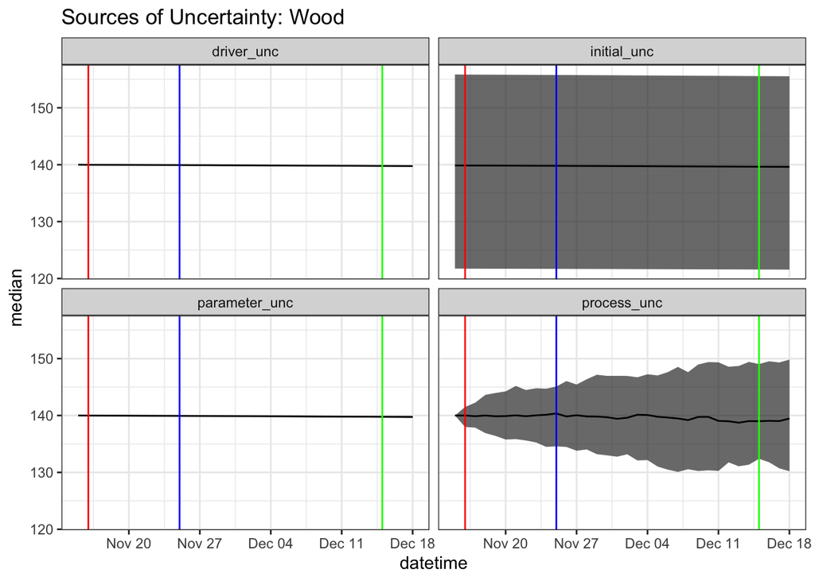

Figure 10: Forecast of each uncertainty source for Wood. One day ahead indicated by red line. Ten days ahead indicated by blue line. Thirty days ahead indicated by green line.

```r
combined_df %>% filter(variable=="wood") %>%
  summarise(median = median(prediction, na.rm = TRUE),
            upper90 = quantile(prediction, 0.95, na.rm = TRUE),
            lower90 = quantile(prediction, 0.05, na.rm = TRUE),
            .by = c("datetime", "model_id")) %>%
  ggplot(aes(x = datetime)) +
  geom_ribbon(aes(ymin = lower90, ymax = upper90), alpha = 0.7) +
  geom_line(aes(y = median)) +
  facet_wrap(~model_id) +
  theme_bw() +
  ggtitle("Sources of Uncertainty: Wood")+
  geom_vline(xintercept=as.Date("2023-11-16"), color="red")+
  geom_vline(xintercept=as.Date("2023-11-25"), color="blue")+
  geom_vline(xintercept=as.Date("2023-12-15"), color="green")
```

### Part 2

Using the code above as a guide, create code to estimate uncertainty based on the propagation all sources at the same time (unlike the one-at-a-time approach above).

Answer with text, code, and plots the following questions

- Plot the forecast with the combined uncertainty.

```r
#ANSWER FROM CLASS - NEED TO PREVENT OVERWRITING PARAMS
new_params <- params
new_params$alpha <- rnorm(ens_members, params$alpha, sd = 0.005)
new_params$sigma.leaf <- rep(0.1, ens_members)
new_params$sigma.stem <- rep(1, ens_members) #0.01 ## wood biomass
new_params$sigma.soil <- rep(1, ens_members)# 0.01

for(t in 2:length(sim_dates)){

  new_output[t, , ]  <- forest_model(t,
                               states = matrix(new_output[t-1 , , 1:3], nrow = ens_members) , #initial condition
                               parms = new_params, #parameter and process
                               inputs = matrix(new_inputs_ensemble[t ,, ], nrow = ens_members)) #driver
}

totalUC_df <- output_to_df(new_output, sim_dates, sim_name = "total_UC")
```

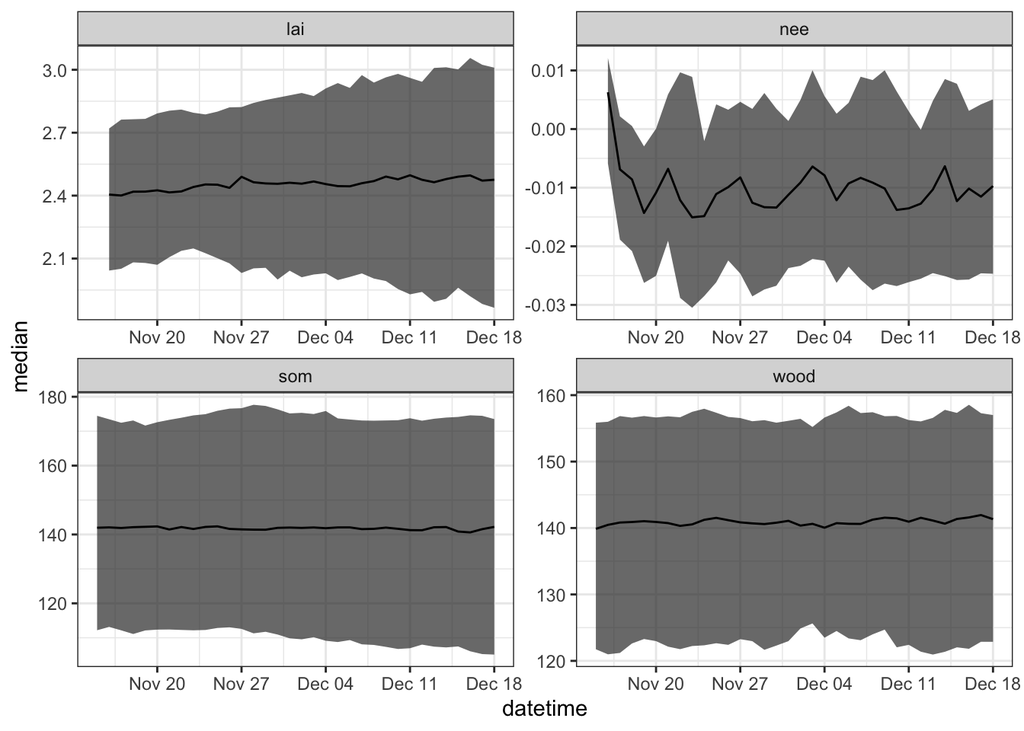

Figure 11: Forecast with combined uncertainty

```r
totalUC_df |>
  filter(variable %in% c("lai", "wood", "som", "nee")) |>
  summarise(median = median(prediction, na.rm = TRUE),
            upper90 = quantile(prediction, 0.95, na.rm = TRUE),
            lower90 = quantile(prediction, 0.05, na.rm = TRUE),
            .by = c("datetime", "variable")) |>
  ggplot(aes(x = datetime)) +
  geom_ribbon(aes(ymin = lower90, ymax = upper90), alpha = 0.7) +
  geom_line(aes(y = median)) +
  facet_wrap(~variable, scale = "free") +
  theme_bw()
```

- If you calculate the variance of the combined uncertainty and compared to the sum of the individual variances, do they match? What does it mean if they are different?

```r
#variance of combined uncertainty
var_df_combo.unc<-totalUC_df %>% group_by(variable, datetime) %>%
  summarize(combo.unc=var(prediction))

#sum of individual variances
var_df_sum.var<-var_df %>% group_by(variable, datetime) %>%
  summarize(sum.var=sum(variance))

#comparison of variances
var.comparison<-left_join(var_df_combo.unc, var_df_sum.var, by=c('variable', 'datetime'))

var.comparison$var.diff<-var.comparison$combo.unc-var.comparison$sum.var
var.comparison
```

```
# A tibble: 408 × 5
# Groups:   variable [12]
   variable datetime   combo.unc   sum.var    var.diff
   <chr>    <date>         <dbl>     <dbl>       <dbl>
 1 gpp      2023-11-15 NA        NA        NA
 2 gpp      2023-11-16  0.000153  0.000137  0.0000162
 3 gpp      2023-11-17  0.000182  0.000160  0.0000217
 4 gpp      2023-11-18  0.000167  0.000160  0.00000660
 5 gpp      2023-11-19  0.000195  0.000188  0.00000638
 6 gpp      2023-11-20  0.000221  0.000217  0.00000463
 7 gpp      2023-11-21  0.000244  0.000214  0.0000293
 8 gpp      2023-11-22  0.000424  0.000376  0.0000477
 9 gpp      2023-11-23  0.000490  0.000452  0.0000383
10 gpp      2023-11-24  0.000256  0.000223  0.0000329
# ℹ 398 more rows
```

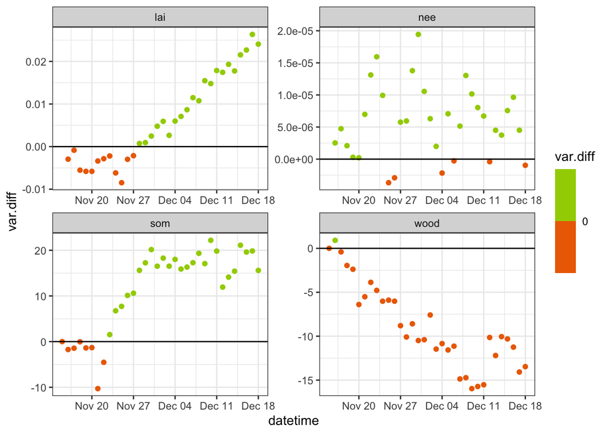

```r
var.comparison %>% filter(variable %in% c("lai", "wood", "som", "nee")) %>%
  ggplot() +
  geom_point(aes(x=datetime, y=var.diff, color=var.diff)) +
  facet_wrap(~variable, scales="free")+
  geom_hline(yintercept=0)+
  theme_bw()+
  scale_color_stepsn(
    colors = c("red", "green"),
    breaks = 0)
```

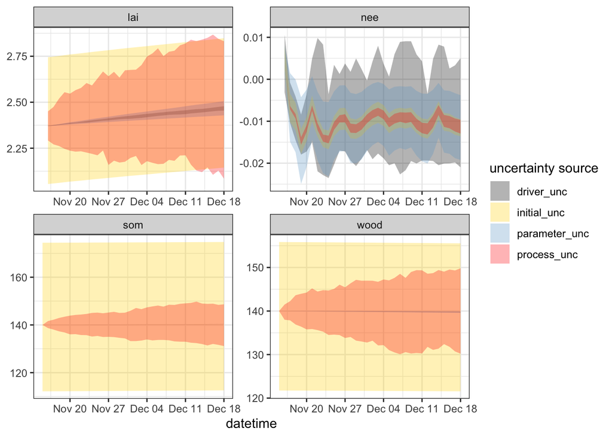

Figure 13: Forecast with all sources of uncertainty, with uncertainties separated by color. Median omited for clarity of image.

```r
combined_df %>% filter(variable %in% c("lai", "wood", "som", "nee")) %>%
  summarise(median = median(prediction, na.rm = TRUE),
            upper90 = quantile(prediction, 0.95, na.rm = TRUE),
            lower90 = quantile(prediction, 0.05, na.rm = TRUE),
            .by = c("datetime", "model_id", "variable")) %>%
  ggplot(aes(x = datetime)) +
  geom_ribbon(aes(ymin = lower90, ymax = upper90, group=model_id, fill=model_id), alpha = 0.3) +
  scale_fill_manual(values=c("black", "gold", "skyblue3", "red"), name="uncertainty source")+
  #geom_line(aes(y = median, color=model_id)) +
  facet_wrap(~variable, scale = "free") +
  theme_bw()
```

END OF ASSIGNMENT

Extra code to ask questions about in class

```r
#MY ATTEMPT AT A DIFFERENT WAY TO PLOT ALL UNCERTAINTY - INCORRECT
# #| warning: FALSE
# #| fig-cap: Forecast with combined uncertainty
# #| label: fig-combo-unc2
# combined_df |>
#   filter(variable %in% c("lai", "wood", "som", "nee")) |>
#   summarise(median = median(prediction, na.rm = TRUE),
#             upper90 = quantile(prediction, 0.95, na.rm = TRUE),
#             lower90 = quantile(prediction, 0.05, na.rm = TRUE),
#             .by = c("datetime", "variable")) |>
#   ggplot(aes(x = datetime)) +
#   geom_ribbon(aes(ymin = lower90, ymax = upper90), alpha = 0.7) +
#   geom_line(aes(y = median)) +
#   facet_wrap(~variable, scale = "free") +
#   theme_bw()
```

```r
#variance of combined uncertainty
# var_df_combo.unc<-combined_df %>% group_by(variable, datetime) %>%
#   summarize(combo.unc=var(prediction))
```